# PSTAT 131 Homework 2

```r
library(tidyverse)
library(tidymodels)
library(ggthemes)
library(yardstick)

abaloneCSV <- read.csv("/Users/joshfreitas/Desktop/pstat 131/abalone.csv")
head(abaloneCSV)
```

```
##   type longest_shell diameter height whole_weight shucked_weight viscera_weight
## 1    M         0.455    0.365  0.095       0.5140         0.2245         0.1010
## 2    M         0.350    0.265  0.090       0.2255         0.0995         0.0485
## 3    F         0.530    0.420  0.135       0.6770         0.2565         0.1415
## 4    M         0.440    0.365  0.125       0.5160         0.2155         0.1140
## 5    I         0.330    0.255  0.080       0.2050         0.0895         0.0395
## 6    I         0.425    0.300  0.095       0.3515         0.1410         0.0775
##   shell_weight rings
## 1        0.150    15
## 2        0.070     7
## 3        0.210     9
## 4        0.155    10
## 5        0.055     7
## 6        0.120     8
```

## Question 1: Adding `age` to the dataset

```r
abaloneData <- mutate(abaloneCSV, age = rings + 1.5)
glimpse(abaloneData)
```

```
## Rows: 4,177
## Columns: 10
## $ type           <chr> "M", "M", "F", "M", "I", "I", "F", "F", "M", "F", "F", …
## $ longest_shell  <dbl> 0.455, 0.350, 0.530, 0.440, 0.330, 0.425, 0.530, 0.545,…
## $ diameter       <dbl> 0.365, 0.265, 0.420, 0.365, 0.255, 0.300, 0.415, 0.425,…
## $ height         <dbl> 0.095, 0.090, 0.135, 0.125, 0.080, 0.095, 0.150, 0.125,…
## $ whole_weight   <dbl> 0.5140, 0.2255, 0.6770, 0.5160, 0.2050, 0.3515, 0.7775,…
## $ shucked_weight <dbl> 0.2245, 0.0995, 0.2565, 0.2155, 0.0895, 0.1410, 0.2370,…
## $ viscera_weight <dbl> 0.1010, 0.0485, 0.1415, 0.1140, 0.0395, 0.0775, 0.1415,…
## $ shell_weight   <dbl> 0.150, 0.070, 0.210, 0.155, 0.055, 0.120, 0.330, 0.260,…
## $ rings          <int> 15, 7, 9, 10, 7, 8, 20, 16, 9, 19, 14, 10, 11, 10, 10, …
## $ age            <dbl> 16.5, 8.5, 10.5, 11.5, 8.5, 9.5, 21.5, 17.5, 10.5, 20.5…
```

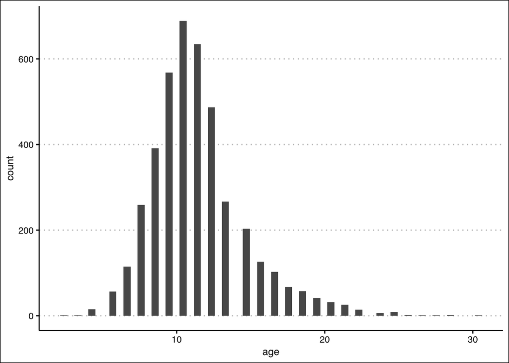

```r
abaloneData %>%
  ggplot(aes(x = age)) +
  geom_histogram(bins = 60) +
  theme_clean()
```

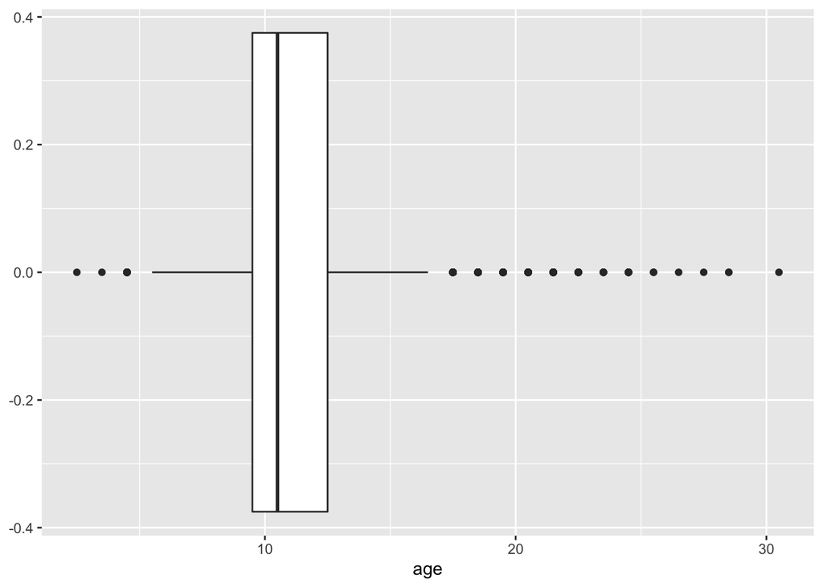

```r
abaloneData %>%
  ggplot(aes(x = age)) + geom_boxplot()
```

From the histogram and boxplot, we can see that the data follows a fairly normal distribution, which is right-skewed. The boxplot indicates that the median age is around 11, and also shows many outliers in the data set.

## Question 2: Splitting the data

```r
set.seed(3162001)

abalone_split <- initial_split(abaloneData, prop = 0.8, strata = age)
abalone_testing <- testing(abalone_split)
abalone_training <- training(abalone_split)

head(abalone_testing); head(abalone_training)
```

```
##    type longest_shell diameter height whole_weight shucked_weight
## 2     M         0.350    0.265  0.090       0.2255         0.0995
## 5     I         0.330    0.255  0.080       0.2050         0.0895
## 21    M         0.355    0.280  0.095       0.2455         0.0955
## 27    F         0.580    0.450  0.185       0.9955         0.3945
## 34    F         0.680    0.550  0.175       1.7980         0.8150
## 39    F         0.575    0.445  0.135       0.8830         0.3810
##    viscera_weight shell_weight rings  age
## 2          0.0485        0.070     7  8.5
## 5          0.0395        0.055     7  8.5
## 21         0.0620        0.075    11 12.5
## 27         0.2720        0.285    11 12.5
## 34         0.3925        0.455    19 20.5
## 39         0.2035        0.260    11 12.5
```

```
##    type longest_shell diameter height whole_weight shucked_weight
## 6     I         0.425    0.300  0.095       0.3515         0.1410
## 17    I         0.355    0.280  0.085       0.2905         0.0950
## 19    M         0.365    0.295  0.080       0.2555         0.0970
## 36    M         0.465    0.355  0.105       0.4795         0.2270
## 38    F         0.450    0.355  0.105       0.5225         0.2370
## 43    I         0.240    0.175  0.045       0.0700         0.0315
##    viscera_weight shell_weight rings age
## 6          0.0775        0.120     8 9.5
## 17         0.0395        0.115     7 8.5
## 19         0.0430        0.100     7 8.5
## 36         0.1240        0.125     8 9.5
## 38         0.1165        0.145     8 9.5
## 43         0.0235        0.020     5 6.5
```

## Question 3: Creating a recipe to predict `age` from other predictor variables

```r
simple_abalone_recipe <- recipe(age ~ type + longest_shell + diameter + height + whole_weight
                                + shucked_weight + viscera_weight + shell_weight, data = abalone_training)
simple_abalone_recipe
```

```
## Recipe
##
## Inputs:
##
##       role #variables
##    outcome          1
##  predictor          8
```

```r
abalone_recipe <- recipe(age ~ type + longest_shell + diameter + height + whole_weight
                                + shucked_weight + viscera_weight + shell_weight, data = abalone_training) %>%
  step_dummy(all_nominal_predictors()) %>%
  step_interact(terms = ~ starts_with('type'):shucked_weight + longest_shell:diameter + shucked_weight:shell_weight) %>%
  step_normalize(all_predictors())
abalone_recipe
```

```
## Recipe
##
## Inputs:
##
##       role #variables
##    outcome          1
##  predictor          8
##
## Operations:
##
## Dummy variables from all_nominal_predictors()
## Interactions with starts_with("type"):shucked_weight + longest_shell...
## Centering and scaling for all_predictors()
```

We don’t use `rings` to predict `age` because we have already defined `age` to be an exact function of `rings`. If we did use `rings` in our model, we would have a predictor that will perfectly predict `age`, and thus would create a model that is not accurate or useful.

## Question 4: Creating a `lm` linear model

```r
lm_model <- linear_reg() %>%
  set_engine('lm')
```

## Question 5: Setting up a workflow

```r
lm_wflow <- workflow() %>%
  add_model(lm_model) %>%
  add_recipe(abalone_recipe)
```

## Question 6: Using `fit()` to find the predicted age

```r
lm_fit <- fit(lm_wflow, abalone_training)
lm_fit %>%
  extract_fit_parsnip() %>%
  tidy()
```

```
## # A tibble: 14 × 5
##    term                          estimate std.error statistic  p.value
##    <chr>                            <dbl>     <dbl>     <dbl>    <dbl>
##  1 (Intercept)                     11.4      0.0374   306.    0
##  2 longest_shell                    0.417    0.290      1.44  1.50e- 1
##  3 diameter                         2.19     0.321      6.84  9.24e-12
##  4 height                           0.258    0.0692     3.73  1.94e- 4
##  5 whole_weight                     4.88     0.389     12.5   2.94e-35
##  6 shucked_weight                  -4.28     0.254    -16.8   4.70e-61
##  7 viscera_weight                  -0.937    0.154     -6.07  1.41e- 9
##  8 shell_weight                     1.47     0.214      6.87  7.59e-12
##  9 type_I                          -0.919    0.113     -8.13  5.97e-16
## 10 type_M                          -0.251    0.102     -2.45  1.45e- 2
## 11 type_I_x_shucked_weight          0.473    0.0859     5.50  4.04e- 8
## 12 type_M_x_shucked_weight          0.308    0.109      2.83  4.74e- 3
## 13 longest_shell_x_diameter        -2.62     0.405     -6.47  1.13e-10
## 14 shucked_weight_x_shell_weight   -0.111    0.205     -0.540 5.89e- 1
```

```r
fakeAbalone <- data.frame(type = 'F', longest_shell = 0.50, diameter = 0.10, height = 0.30, whole_weight = 4, shucked_weight = 1, viscera_weight = 2, shell_weight = 1, rings = 9)

predict(lm_fit, new_data = fakeAbalone)
```

```
## # A tibble: 1 × 1
##   .pred
##   <dbl>
## 1  21.7
```

From our predict() function, we could see that the predicted age of thus hypothetical abalone would be **21.73369**.

## Question 7: Assessing model performance with `yardstick`

```r
abalone_training_res <- predict(lm_fit, new_data = abalone_training %>% select(-age))
head(abalone_training_res)
```

```
## # A tibble: 6 × 1
##   .pred
##   <dbl>
## 1  9.30
## 2  9.70
## 3 10.4
## 4 10.1
## 5 10.9
## 6  6.23
```

```r
abalone_training_res <- bind_cols(abalone_training_res, abalone_training %>% select(age))
head(abalone_training_res)
```

```
## # A tibble: 6 × 2
##   .pred   age
##   <dbl> <dbl>
## 1  9.30   9.5
## 2  9.70   8.5
## 3 10.4    8.5
## 4 10.1    9.5
## 5 10.9    9.5
## 6  6.23   6.5
```

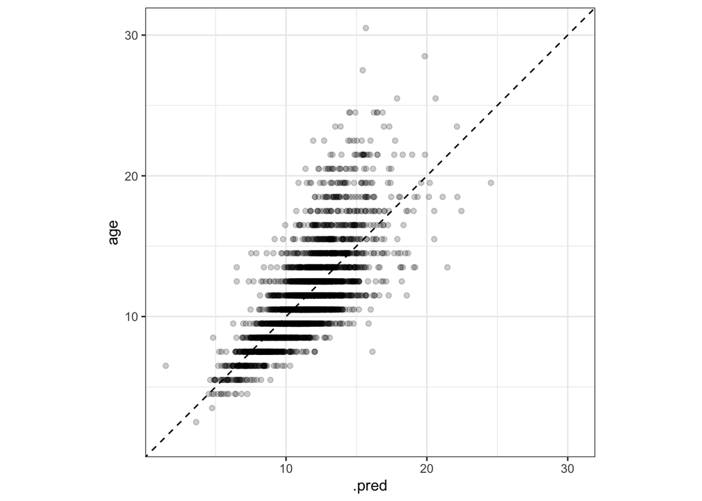

```r
abalone_training_res %>%
  ggplot(aes(x = .pred, y = age)) +
  geom_point(alpha = 0.2) +
  geom_abline(lty = 2) +
  theme_bw() +
  coord_obs_pred()
```

```r
abalone_metrics <- metric_set(rmse, rsq, mae)
abalone_metrics(abalone_training_res, truth = age,
                estimate = .pred)
```

```
## # A tibble: 3 × 3
##   .metric .estimator .estimate
##   <chr>   <chr>          <dbl>
## 1 rmse    standard       2.16
## 2 rsq     standard       0.548
## 3 mae     standard       1.54
```

Our metrics have produced a `rmse`=**2.1556964**, `rsq`=**0.5477235**, and `mae`=**1.5447322**. Generally, the RMSE and MAE are high, indicating that the residuals of the model are high and thus that they are spread out and at a high magnitude. The `rsq` value of 0.5477235 indicate that only 54.77% of the variability in age of the abalone can be predicted by our model, which is a weak relationship. Thus, based on the predictors we were provided and our interactions, we would say that these are not effective at predicting the age of an abalone.